# John Baffes

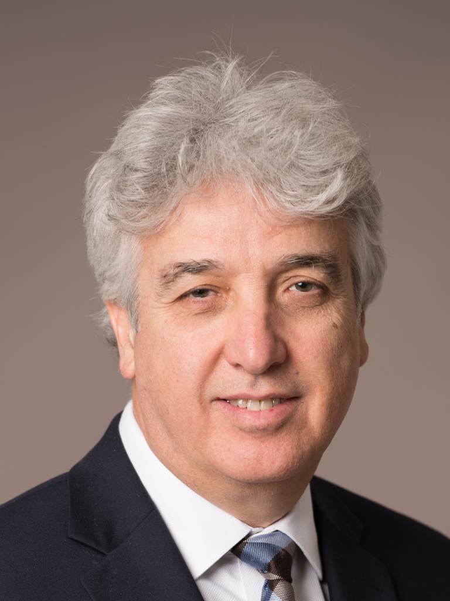

**Presentation Title:** Global Food Price Inflation: Trends, Channels, and Insights

**Abstract:** During 2021-23, most countries experienced food price inflation at rates not seen since the late 1970s and early 1980s. For example, during 2022-23, food price inflation in the U.S. averaged 7.2 percent year-on-year, while in the Euro area, it was even higher at 12.6 percent. Both advanced and emerging market economies faced similar inflationary pressures. This inflation spike is not limited to food; headline inflation, which includes both food and energy (typically seen as volatile components of the consumption basket), and core inflation, which excludes them, followed similar patterns.

In response, most central banks took decisive action by aggressively increasing policy rates. Although both core and headline inflation began to ease in the third quarter of 2023, they remain above central bank target levels, prompting caution in easing monetary policy. The literature identifies several key factors behind the recent inflationary pressures for food items. These include supply chain disruptions during the pandemic, the war in Ukraine, wage increases in response to tight labor markets, and fiscal policies aimed at boosting consumption during the pandemic to avert recession. Other contributing factors, though discussed less frequently in academic literature and more in the popular press and media, include short-term elements such as speculation and price hikes by food companies, as well as longer-term factors such as demand growth driven by rising incomes and population increases, and the impacts of climate change. High energy prices have been a significant transmission channel for both food price inflation and overall inflation. Additionally, higher primary food commodity prices, especially for grains and oilseeds, have further contributed to the recent inflationary trend, though to a lesser extent than energy. However, unlike the food price spikes of 2007-08 and 2010-11, which were associated with tight supply conditions, global supplies during the past few seasons have been adequate, though tightening. For example, aggregate global inventories for food commodities, measured by the stock-to-use ratio, are currently at 27 percent, down from 31 percent in 2018 but significantly higher than 17 percent in 2007. The presentation concludes that the recent inflationary pressures are primarily associated with cost factors rather than supply shortfalls or excessive demand.